# Confirmation Analysis - Blogpost

TerR Squad: Frank Gonzalez, Hunter Watkins, Chanyoung Woo

5/11/2021

## Exploration 1:

For our second hypothesis, we wanted to see if there was any association between the Season of the year and the Time of Day each trip is taken.

We provide a couple helpful definitions:

- Null Hypothesis: There is no association between Season and ToD of trips taken.
- Alternative Hypothesis: There is an association between Season and ToD of trips taken.

### Tests

Before taking a look at the data further we decided to take a preliminary test to see if there were any associations between Season of the year and the Time of the Day each trip was taken. We can see in the first table, our current data we have, split between different seasons and time of the day.

```
##
##          Morning Lunch Afternoon Evening Night
##   Spring       3    23        70      86    35
##   Summer      25    59        90     135    77
##   Fall        25    71       129     198    91
```

We then did a quick test to see if Season had any impact on the time of day people rode the bikes. From the results, we concluded that Season did in fact have some association to the time of day, meaning that depending on the season of year, people took trips on different times of the day.

```
##
##  Pearson's Chi-squared test
##
## data:  table(train20.confirmation$Season, train20.confirmation$ToD)
## X-squared = 16.669, df = 8, p-value = 0.03375
```

For the third table, we just have a few values of what the computer thought our data was supposed to look like, but it differs slightly from the real life values we see in the first table.

```
##
##           Morning    Lunch Afternoon   Evening    Night
##   Spring 10.29633 29.72337  56.14414  81.39928 39.43688
##   Summer 18.31513 52.87198  99.86929 144.79320 70.15040
##   Fall   24.38854 70.40466 132.98657 192.80752 93.41271
```

### Graphics

We now show a few graphs to help understand more about the variables being tested and also to show a comparison between the observed and expected values.

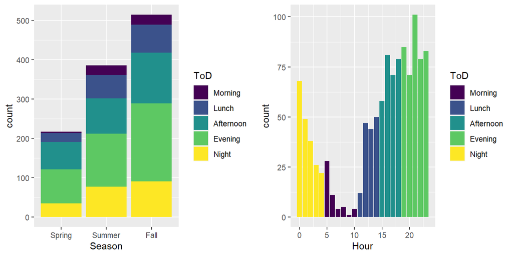

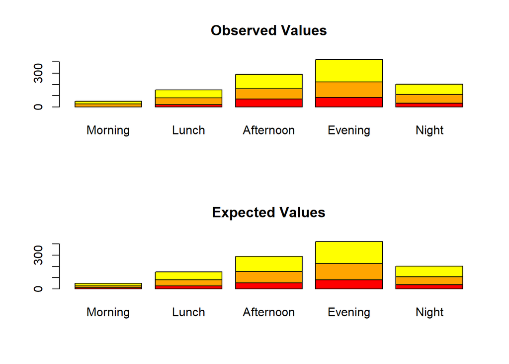

We then include a faceted graph to graphically summarize the content by time:

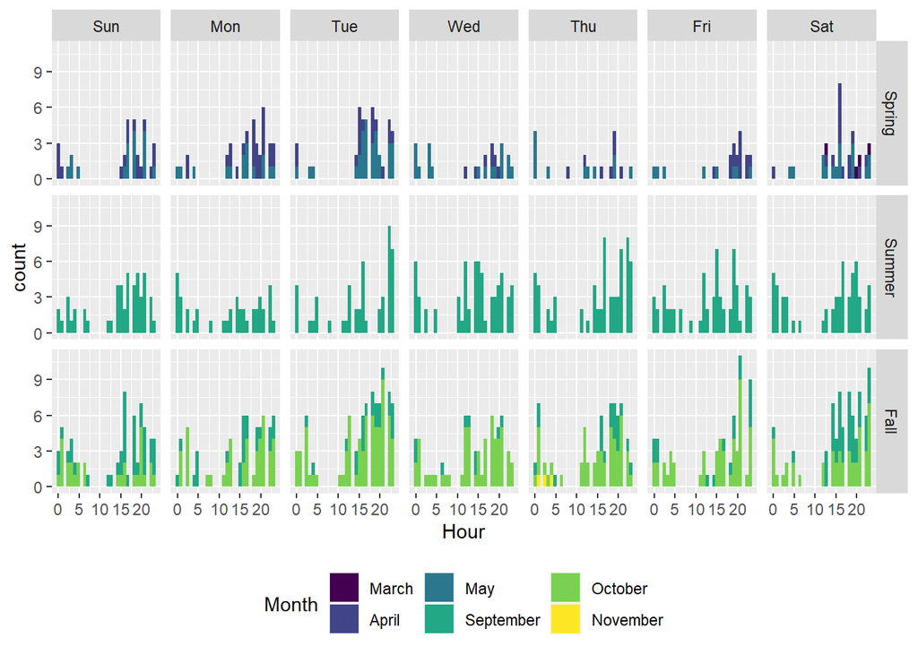

### Conclusion

To see if there was any association between Season and Time of Day, we performed a chi-squared test to check. From the results, we found the chi-squared test statistic to = 16.669 this time and the p-value to = 0.03375. We took a look at the expected values again to see if they were significantly different than the current observed values. This time, the p-values for this test were lower than the last hypothesis, and because we assume alpha = 0.05, we reject the null hypothesis, which just means that we found that the difference matters, and conclude that there is an association between the Season of the year and what Time of Day the trip occurs.

## Exploration 2: Does Destination Depend on Time?

This exploration of the data is largely a simple hypothesis meant to discover if people are going different places depending on the time. Times of day are designated as above where the variable itself is labeled `ToD`.

As before, we begin with broad look with the intention of magnifying the results to get a better look at the data as a whole.

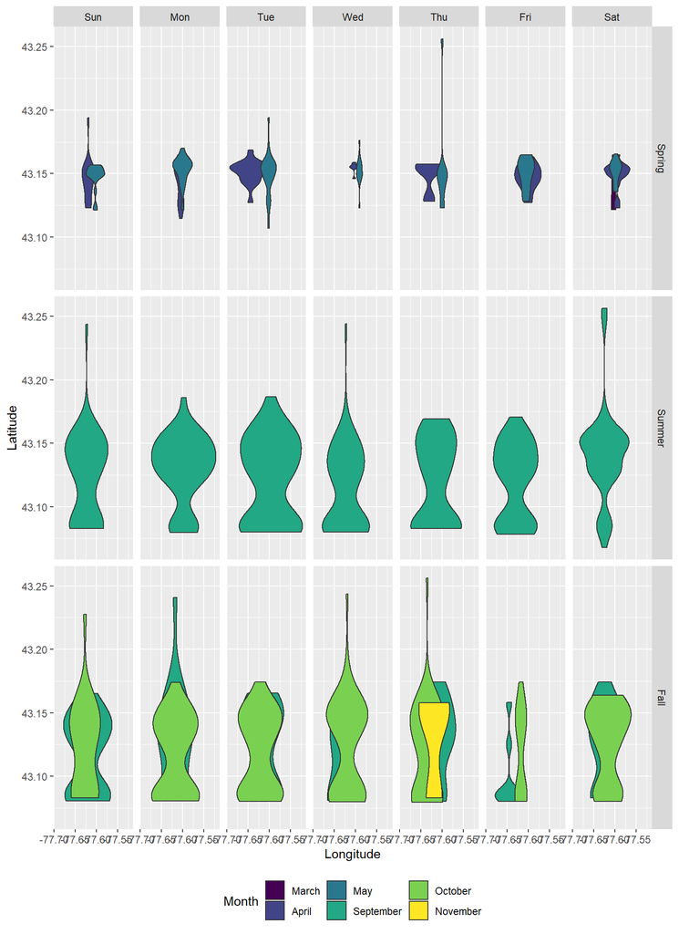

We now start the magnification of the above faceted graph. We begin with a series of violin boxplots in an attempt to note any differences that may not have been apparent in the holistic graph. This series is done with a lens on `Longitude`.

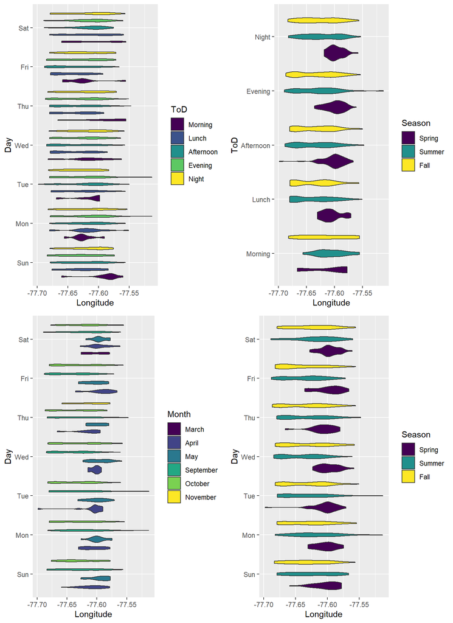

Similar to the above chunk, but with a focus on `Latitude`:

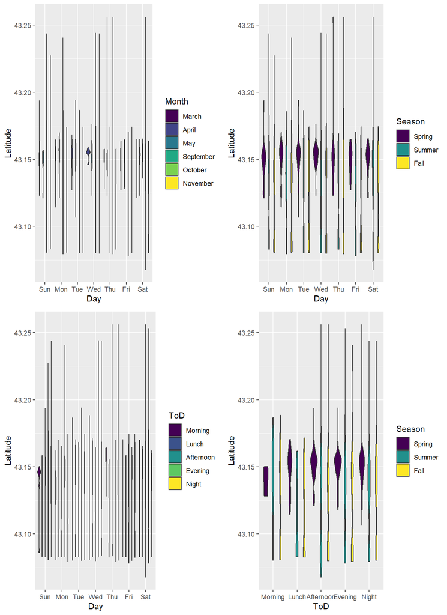

We zoom in on the data from another direction, with a series of ridgeline graphs.

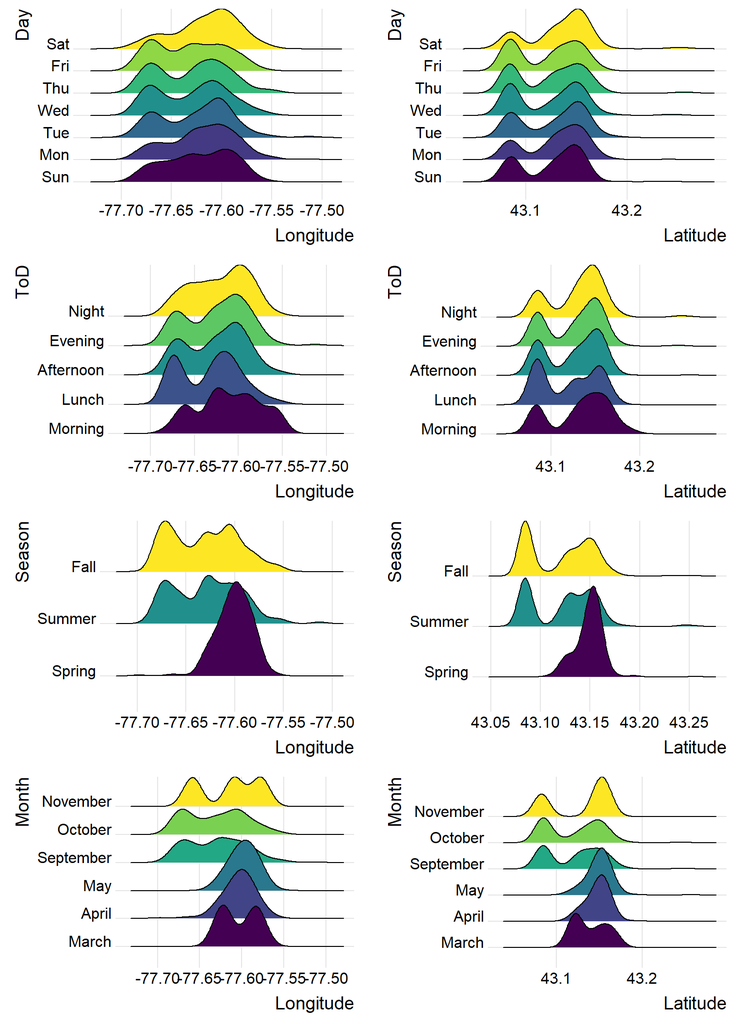

We notice that there are significant differences based on `Season` and `Month` when compared to both `Latitude` and `Longitude`. We also find that the days of the week have very similar curves, excluding weekends, and maybe surprisingly, that `ToD` has similar curves throughout.

Here we incorporate interactive density histograms that illustrate the differences in location by `Month` and `ToD`.

[interactive chart not shown]

In the above graphs, we should pay particular notice to the graphs with ranges, they may be skewing the data due to smaller samples, which is corroborated by the below tables.

```
##
##     March     April       May September   October  November
##         4        98       115       549       348         3
```

```
##
##   Morning     Lunch Afternoon   Evening     Night
##        53       153       289       419       203
```

Fun animated graph that shows how the locations change by time of day:

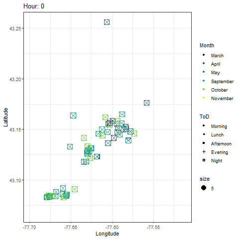

### Conclusion:

This exploration emphasizes the importance of sample size. With smaller samples, we can end up with variant ranges by both `Latitude` and `Longitude`, skewing our perception of popular and not so popular destinations based on time.

## Exploration 3: Are Rochester college students the drive of bike rental business?

When originally looking at the different frequency of trips within seasons, it was taken notice that there tends to be more trips in the fall. Interestingly enough, it is around the same time that University students at the University of Rochester and RIT return or begin classes for their freshman year.

For instance, in this initial graph, notice the areas of concentration. These areas, unsurprisingly, are at the local universities and the central city:

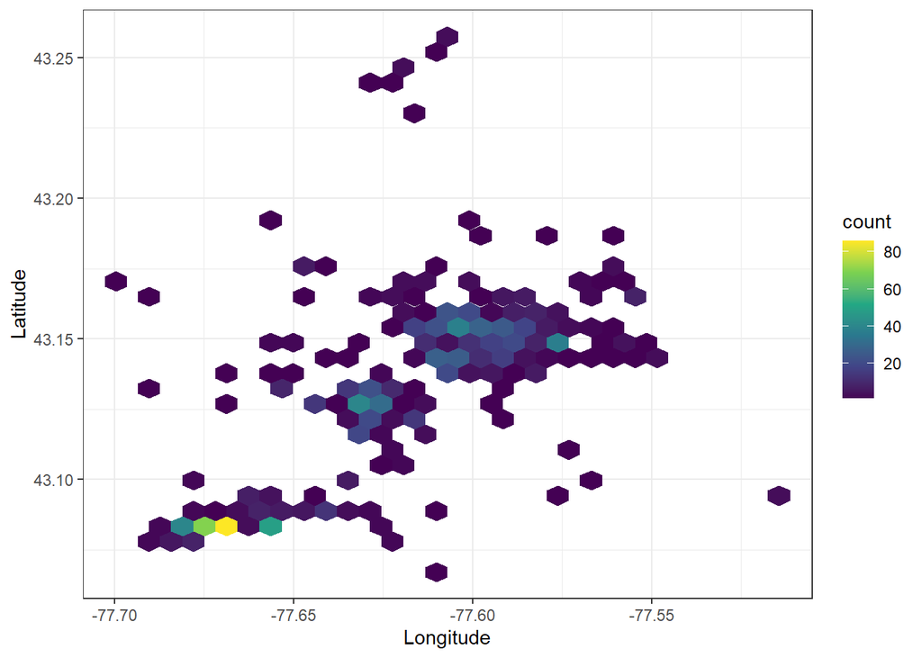

Please refer to the University of Rochester(UofR) and Rochester Institute of Technology(RIT)’s start of classes for the fall of 2018:

[Rochester 2018](http://www.rochester.edu/provost/assets/PDFs/Academic%20Calendar%202011-2021_FINAL.pdf)

[RIT 2018](https://www.rit.edu/calendar/1819)

*UofR start of classes(2018): 8/30*

*Eastman School of Music start of classes(2018): 8/28*

*RIT start of classes(2018): 8/27*

We want to observe if the influx of trips, with a focus on new students, is correlated with the beginning of fall semesters at UofR and RIT.

### T-test, Formal Approach, Location

We want to say that the $H_0$ = No significant difference between season and $H_1$ = There is a significant difference.

```
##
##  Welch Two Sample t-test
##
## data:  Fall and Spring
## t = -0.0083657, df = 814.09, p-value = 0.9933
## alternative hypothesis: true difference in means is not equal to 0
## 95 percent confidence interval:
##  -6.819441  6.761559
## sample estimates:
## mean of x mean of y
## -17.25491 -17.22597
```

We used a t-test because we wanted to determine if there is a significant difference between the locations of bike trips. We took a closer look at Spring and Fall because these are the two seasons have the biggest differences. That being that RIT bike trips were “removed” in the Spring season. However our resulting t-test returned that the there is no significant difference between the location of the trips. The density of trips is still within the academic institutions that is UofR, its Eastman School in Downtown Rochester, and The City of Rochester itself.

In technical terms: We want to say that the $H_0$ = No significant difference between season and $H_1$ = There is a significant difference.

Here we include an animated graph of the map populated by season:

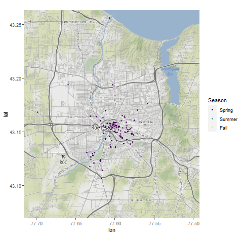

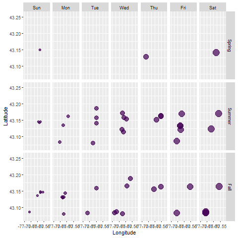

### Conclusion:

In conclusion, although we performed a technical approach into interpreting location density and seasons, we did not find the statistical results we wanted. This, however, is not necessarily a negating factor and we are still able to provide valuable information as to explain that academic student bodies are the driving force of a city. It is clear, from our seasons and background information on class schedules, that bike-sharing should take note of the student life in Rochester.

## Final Conlusion:

In the introduction, we began to talk about how we wanted to see where the bike trips were most being used. Before reaching our final conclusion, we took a few preliminary tests to see if some variables had any associations with each other. Afterwards we proceeded to produce some visual graphs to further help explain our hypothesis. Finally, we plotted the latitude and longitude and placed the results over the map of the Rochester area.

What we discovered after doing all our tests, we found that the 3 locations that use the bikes most are located at the UofR, RIT, and a little around downtown Rochester. We also found that these mikes are most used during the evening hours around 9 to 12pm. Something interesting we noticed was that the number of trips increased in parallel to the start of classes at both Universities.